# Score Analysis

## Data & Packages

```r
list.of.packages <- c("mirt", "ltm", "TAM", "dplyr")
new.packages <- list.of.packages[!(list.of.packages %in% installed.packages()[,"Package"])]
if(length(new.packages)) install.packages(new.packages, repos = "http://cran.us.r-project.org")
lapply(list.of.packages, library, character.only = TRUE)

score <- read.csv('正式测试/score.csv')
score.pre <- score[2:5]
score.mid1 <- score[6:9]
score.mid2 <- score[10:13]
score.post <- score[14:17]
```

```r
linking <- read.csv('正式测试/linking.csv')
linking.q1 <- score[2:5]
linking.q2 <- score[6:9]
linking.q3 <- score[10:13]
```

## GRM

对于pre和post，将两组数据整合后统一调用GRM模型，随后再将被试参数分成两组。对于两次中测则保留原始结构。

```r
names(score.pre) <- c("T1", "T2", "T3", "T4")
names(score.post) <- c("T1", "T2", "T3", "T4")
```

```r
grm.pre.post <- mirt(data = rbind(score.pre, score.post), itemtype = rep("graded",4))
grm.theta.preNpost <- fscores(grm.pre.post) # 被试参数估计
grm.theta.pre <- grm.theta.preNpost[1:40]
grm.theta.post <- grm.theta.preNpost[41:80]
grm.coef.pre <- coef(grm.pre.post, IRTpars=T)  # 项目参数估计
grm.coef.post <- coef(grm.pre.post, IRTpars=T)

grm.mid1 <- mirt(data = score.mid1, itemtype = rep("graded",4))
grm.theta.mid1 <- fscores(grm.mid1)

grm.mid2 <- mirt(data = score.mid2, itemtype = rep("graded",4))
grm.theta.mid2 <- fscores(grm.mid2)
```

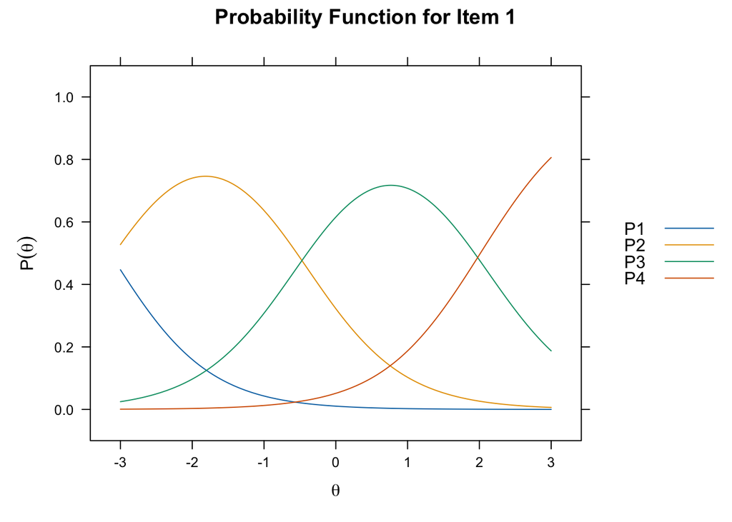

```r
itemplot(grm.pre.post,item = 1,theta_lim = c(-3,3),type = "trace")
```

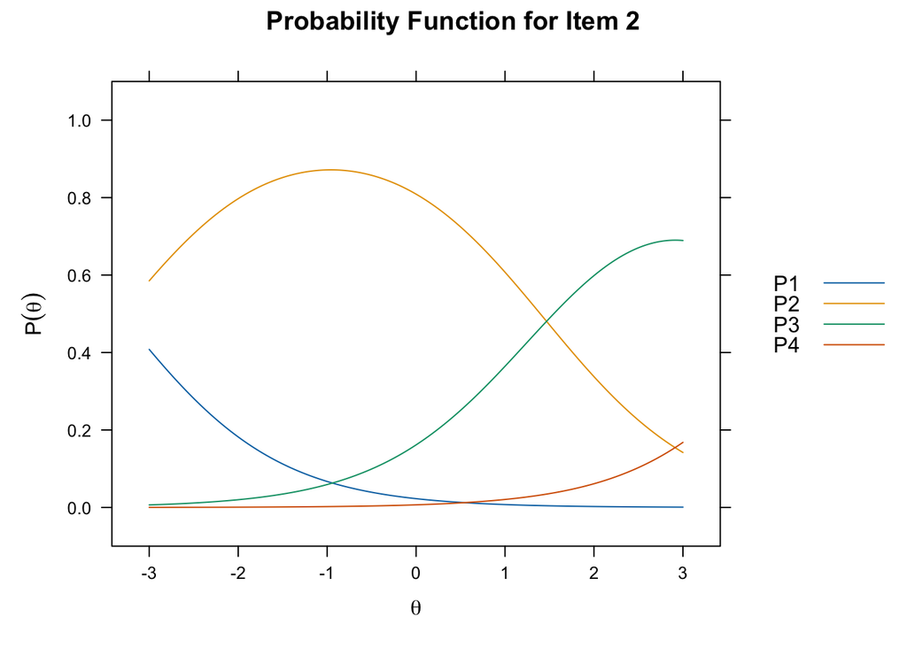

```r
itemplot(grm.pre.post,item = 2,theta_lim = c(-3,3),type = "trace")
```

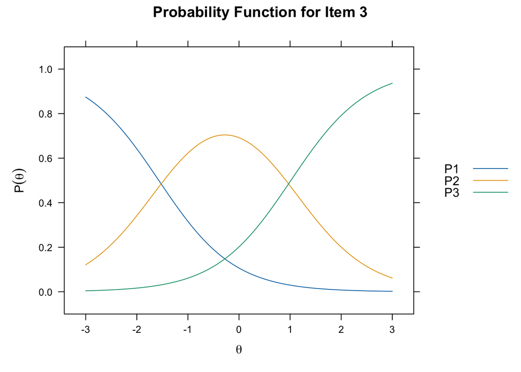

```r
itemplot(grm.pre.post,item = 3,theta_lim = c(-3,3),type = "trace")
```

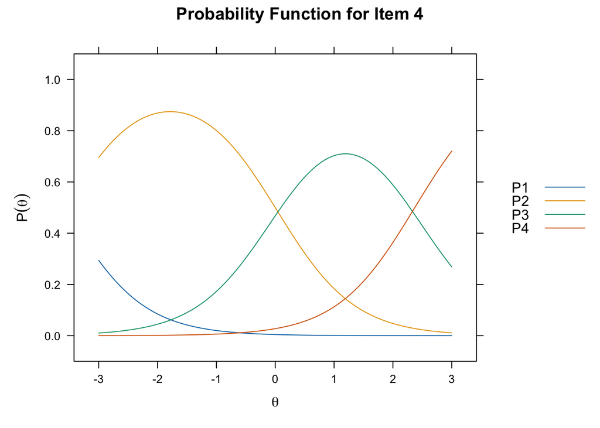

```r
itemplot(grm.pre.post,item = 4,theta_lim = c(-3,3),type = "trace")
```

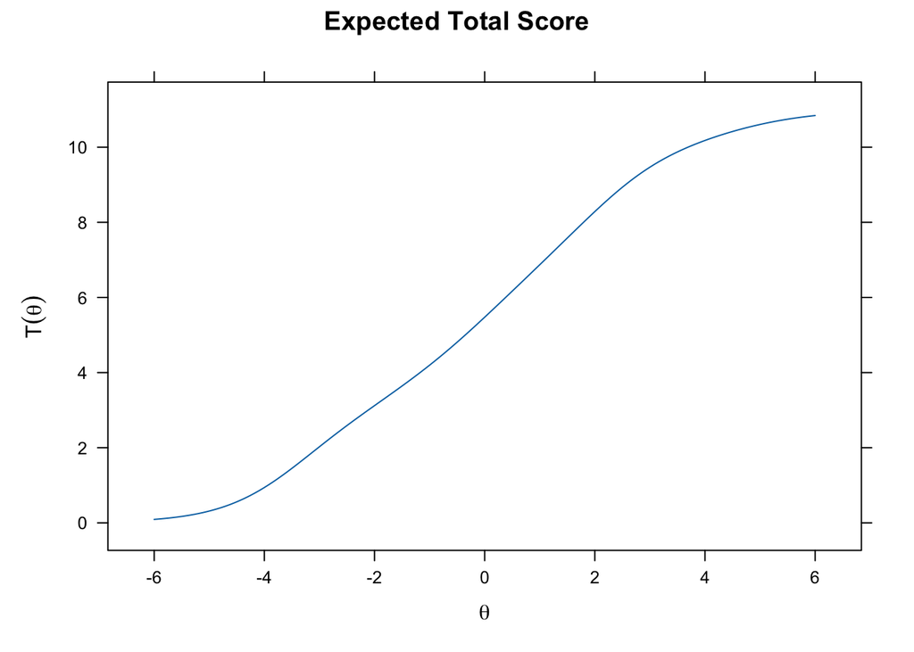

```r
plot(grm.pre.post) # 期望总分
```

linking部分，先计算linking数据的参数

```r
grm.q1 <- mirt(data = linking.q1, itemtype = rep("graded",4))
grm.q2 <- mirt(data = linking.q2, itemtype = rep("graded",4))
grm.q3 <- mirt(data = linking.q3, itemtype = rep("graded",4))

grm.theta.q1 <- fscores(grm.q1)
grm.theta.q2 <- fscores(grm.q2)
grm.theta.q3 <- fscores(grm.q3)
```

linking应当服从变换：
$$\theta_1 = A_{k}\theta_k+B_{k}$$
其中，$k=2,3$且变换参数满足：
$$A_k=\frac{\sigma(\theta_1)}{\sigma(\theta_k)},\\
B_k=\mu(\theta_1)-A_k\mu(\theta_k)$$

```r
sigma1 <- sd(grm.theta.q1)
sigma2 <- sd(grm.theta.q2)
sigma3 <- sd(grm.theta.q3)

mu1 <- mean(grm.theta.q1)
mu2 <- mean(grm.theta.q2)
mu3 <- mean(grm.theta.q3)

A2 <- sigma1/sigma2
B2 <- mu1 - A2*mu2
A3 <- sigma1/sigma3
B3 <- mu1 - A3*mu3
```

最后对于测量数据做linking，全部都以卷1为标准：

```r
grm.theta.pre.linked <- grm.theta.pre
grm.theta.mid1.linked <- A2 * grm.theta.mid1 + B2
grm.theta.mid2.linked <- A3 * grm.theta.mid2 + B3
grm.theta.post.linked <- grm.theta.post


grm.theta <- cbind(grm.theta.pre.linked, grm.theta.mid1.linked, grm.theta.mid2.linked, grm.theta.post.linked)
write.csv(grm.theta, "正式测试/result.csv")
```

## GPCM

```r
gpcm.pre <- mirt(data = score.pre, itemtype = rep("gpcm",4))
gpcm.theta.pre <- fscores(gpcm.pre) # 被试参数估计
gpcm.coef.pre <- coef(gpcm.pre, IRTpars=T)  # 项目参数估计
```

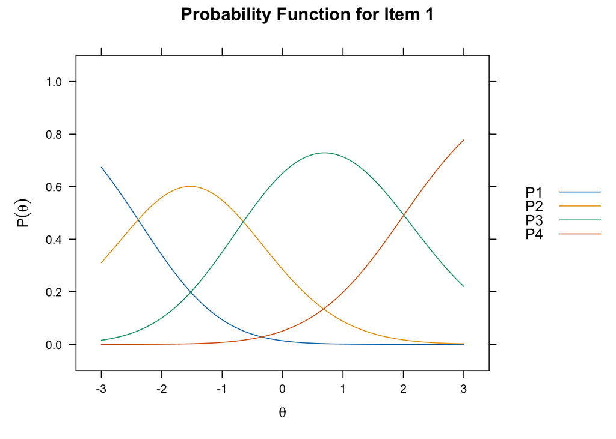

```r
itemplot(gpcm.pre,item = 1,theta_lim = c(-3,3),type = "trace")
```

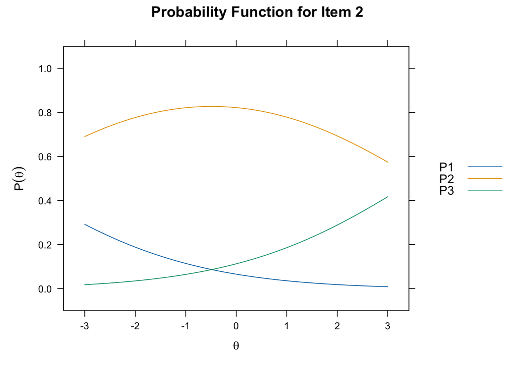

```r
itemplot(gpcm.pre,item = 2,theta_lim = c(-3,3),type = "trace")
```

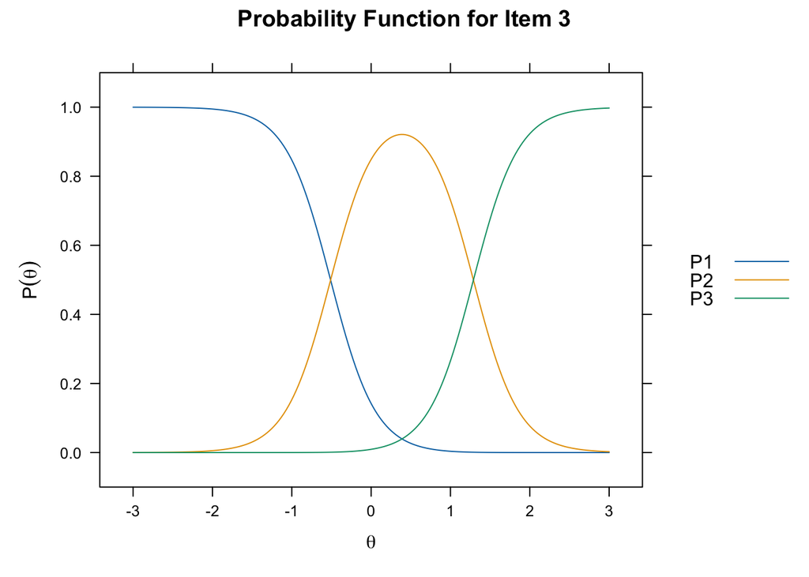

```r
itemplot(gpcm.pre,item = 3,theta_lim = c(-3,3),type = "trace")
```

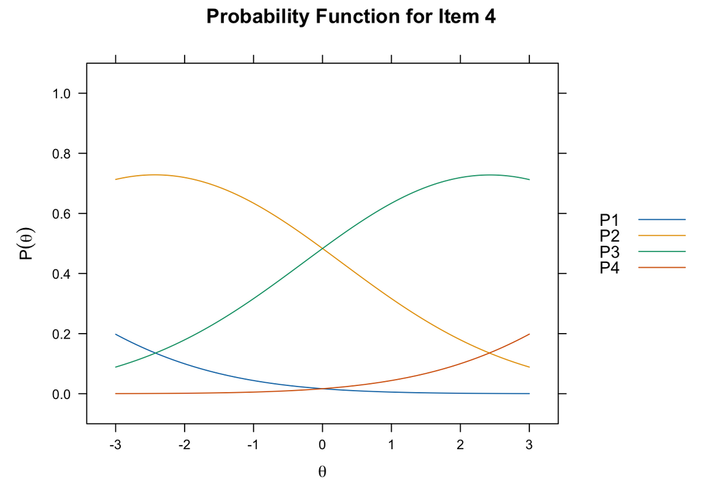

```r
itemplot(gpcm.pre,item = 4,theta_lim = c(-3,3),type = "trace")
```

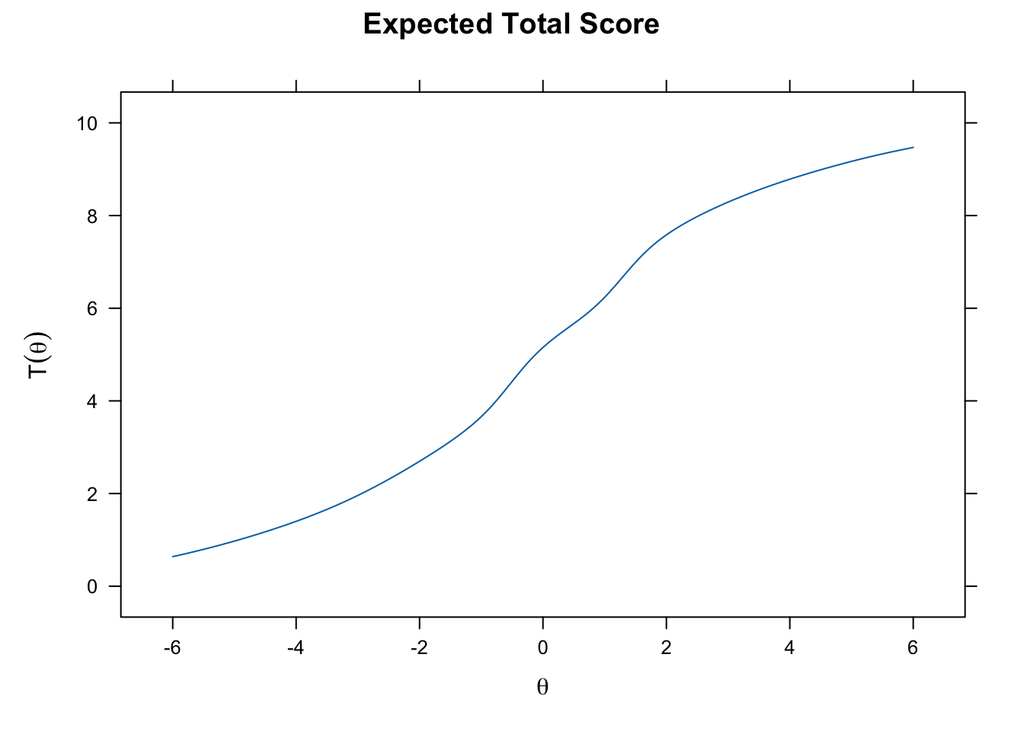

```r
plot(gpcm.pre)
```

## PCM

```r
pcm.pre <- mirt(data = score.pre, itemtype = rep("Rasch",4))
pcm.theta.pre <- fscores(pcm.pre) # 被试参数估计
pcm.coef.pre <- coef(pcm.pre, IRTpars=T)  # 项目参数估计
```

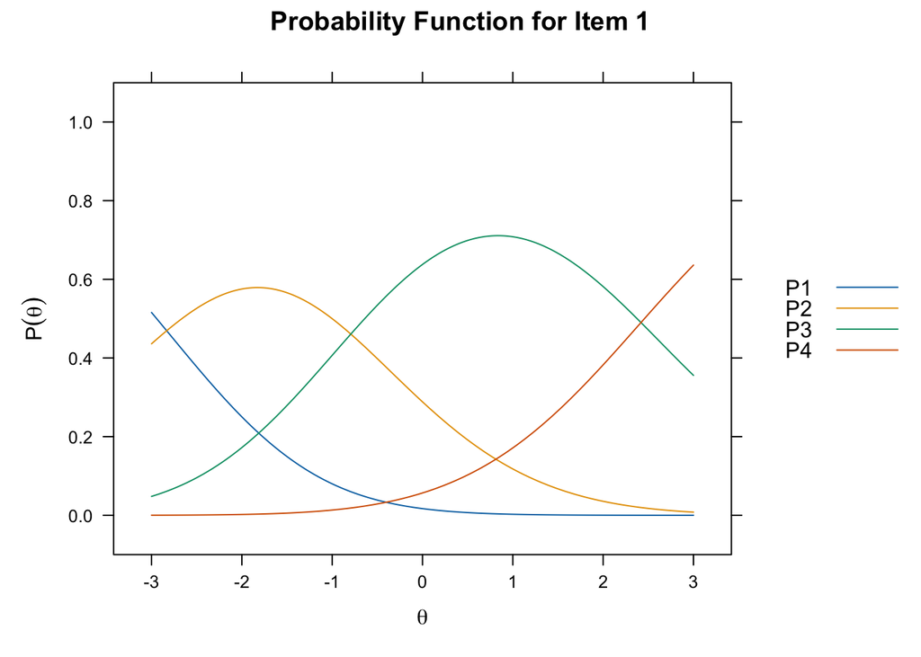

```r
itemplot(pcm.pre,item = 1,theta_lim = c(-3,3),type = "trace")
```

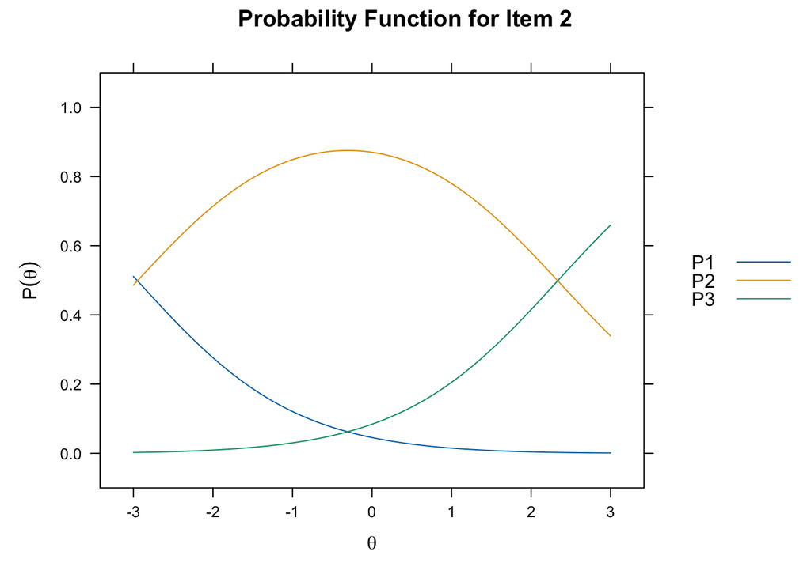

```r
itemplot(pcm.pre,item = 2,theta_lim = c(-3,3),type = "trace")
```

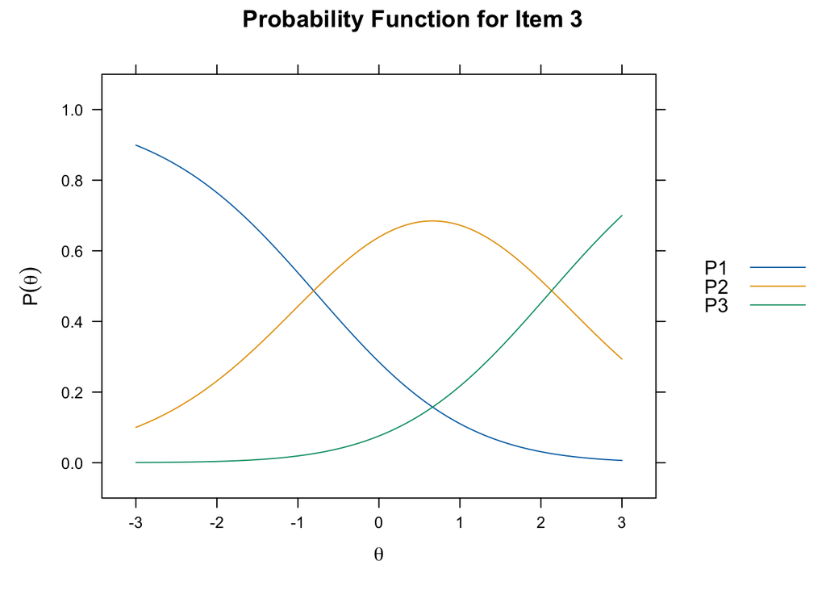

```r
itemplot(pcm.pre,item = 3,theta_lim = c(-3,3),type = "trace")
```

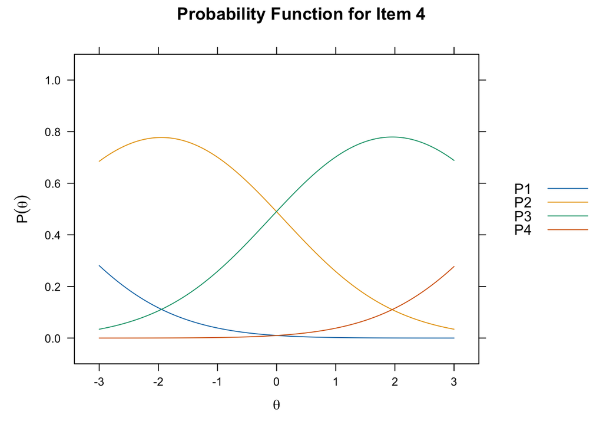

```r
itemplot(pcm.pre,item = 4,theta_lim = c(-3,3),type = "trace")
```

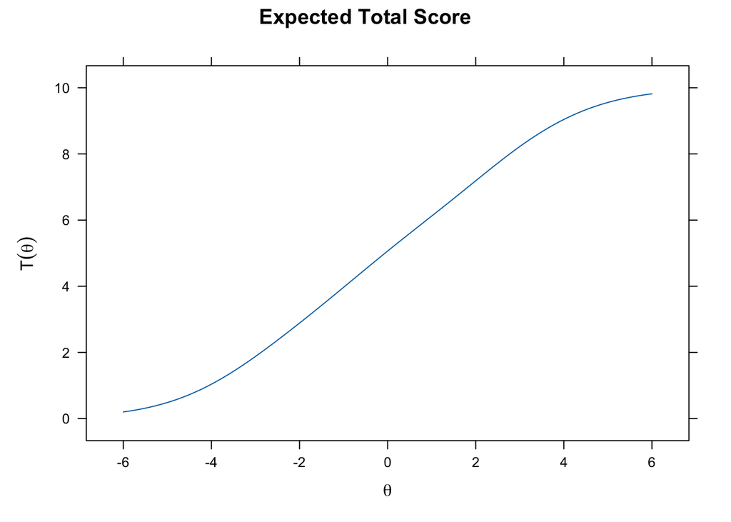

```r
plot(pcm.pre) # 期望总分
```

## MFRM

```r
mfr.pre <- tam.mml.mfr(score.pre)
```

[output not shown]

[output cut: 720 more lines]

```
##      [,1]
## [1,]    0
##
## Variance:
##      [,1]
## [1,] 1.28
##
##
## EAP Reliability:
## [1] 0.578
##
## -----------------------------
## Start:  2023-06-28 17:18:33.766652
## End:  2023-06-28 17:18:33.909025
## Time difference of 0.1423728 secs
```

$$\theta_2 =
\frac{\sigma(\theta_2)}{\sigma(\theta_1)}\theta_1+\mu(\theta_2)-\frac{\sigma(\theta_2)}{\sigma(\theta_1)}\mu(\theta_1)$$
$$\theta_3 =
\frac{\sigma(\theta_3)}{\sigma(\theta_2)}\theta_2+\mu(\theta_3)-\frac{\sigma(\theta_3)}{\sigma(\theta_2)}\mu(\theta_2)\\
=\frac{\sigma(\theta_3)}{\sigma(\theta_2)}
\left[\frac{\sigma(\theta_2)}{\sigma(\theta_1)}\theta_1+\mu(\theta_2)-\frac{\sigma(\theta_2)}{\sigma(\theta_1)}\mu(\theta_1)\right]
+\mu(\theta_3)-\frac{\sigma(\theta_3)}{\sigma(\theta_2)}\mu(\theta_2)\\
=\frac{\sigma(\theta_3)}{\sigma(\theta_1)}\theta_1+\mu(\theta_3)-\frac{\sigma(\theta_3)}{\sigma(\theta_1)}\mu(\theta_1)$$

# Examples

## Eg1. 知乎案例

加载需要的包，其中：

- `eRm`：**Extended Rasch Modeling** 用于构建Rasch模型
- `difR`：读取数据

```r
list.of.packages <- c("ltm", "difR", "eRm")
new.packages <- list.of.packages[!(list.of.packages %in% installed.packages()[,"Package"])]
if(length(new.packages)) install.packages(new.packages, repos = "http://cran.us.r-project.org")
lapply(list.of.packages, library, character.only = TRUE)
```

数据采用`difR`包中的`verbal`数据，包含24个测试量和1个性别代码（不纳入考虑，故移除）

```r
data(verbal, package = "difR")
exa.dat <- verbal[, 1:24]
head(exa.dat)
```

```
##   S1wantCurse S1WantScold S1WantShout S2WantCurse S2WantScold S2WantShout
## 1           0           0           0           0           0           0
## 2           0           0           0           0           0           0
## 3           1           1           1           1           0           1
## 4           1           1           1           1           1           1
## 5           1           0           1           1           0           0
## 6           1           1           0           1           0           0
##   S3WantCurse S3WantScold S3WantShout S4WantCurse S4WantScold S4WantShout
## 1           0           0           1           1           0           0
## 2           0           0           0           0           0           0
## 3           1           0           0           0           0           0
## 4           1           0           0           0           0           0
## 5           1           0           0           1           0           0
## 6           1           1           1           0           0           0
##   S1DoCurse S1DoScold S1DoShout S2DoCurse S2DoScold S2DoShout S3DoCurse
## 1         1         0         1         1         0         0         1
## 2         0         0         0         0         0         0         1
## 3         0         1         1         0         0         1         0
## 4         1         1         1         1         1         1         1
## 5         1         1         0         1         0         0         1
## 6         1         0         0         1         0         0         1
##   S3DoScold S3DoShout S4DoCurse S4DoScold S4DoShout
## 1         0         0         1         1         1
## 2         0         0         0         0         0
## 3         0         0         1         0         0
## 4         0         0         0         0         0
## 5         0         0         1         0         0
## 6         0         0         1         1         0
```

```r
res.rm <- RM(exa.dat)
summary(res.rm)
```

```
##
## Results of RM estimation:
##
## Call:  RM(X = exa.dat)
##
## Conditional log-likelihood: -3049.923
## Number of iterations: 31
## Number of parameters: 23
##
## Item (Category) Difficulty Parameters (eta): with 0.95 CI:
##             Estimate Std. Error lower CI upper CI
## S1WantScold   -0.731      0.131   -0.987   -0.475
## S1WantShout   -0.249      0.128   -0.501    0.003
## S2WantCurse   -1.909      0.153   -2.210   -1.608
## S2WantScold   -0.873      0.132   -1.132   -0.614
## S2WantShout   -0.181      0.128   -0.433    0.070
## S3WantCurse   -0.696      0.130   -0.951   -0.440
## S3WantScold    0.514      0.132    0.254    0.773
## S3WantShout    1.358      0.149    1.065    1.650
## S4WantCurse   -1.245      0.137   -1.514   -0.976
## S4WantScold    0.178      0.129   -0.076    0.432
## S4WantShout    0.871      0.138    0.601    1.141
## S1DoCurse     -1.383      0.140   -1.658   -1.109
## S1DoScold     -0.557      0.129   -0.810   -0.303
## S1DoShout      0.698      0.135    0.434    0.963
## S2DoCurse     -1.037      0.134   -1.300   -0.774
## S2DoScold     -0.113      0.128   -0.365    0.138
## S2DoShout      1.312      0.148    1.022    1.602
## S3DoCurse      0.040      0.129   -0.212    0.293
## S3DoScold      1.335      0.149    1.044    1.626
## S3DoShout      2.871      0.222    2.436    3.306
## S4DoCurse     -0.873      0.132   -1.132   -0.614
## S4DoScold      0.213      0.130   -0.042    0.467
## S4DoShout      1.840      0.165    1.516    2.165
##
## Item Easiness Parameters (beta) with 0.95 CI:
##                  Estimate Std. Error lower CI upper CI
## beta S1wantCurse    1.383      0.140    1.109    1.658
## beta S1WantScold    0.731      0.131    0.475    0.987
## beta S1WantShout    0.249      0.128   -0.003    0.501
## beta S2WantCurse    1.909      0.153    1.608    2.210
## beta S2WantScold    0.873      0.132    0.614    1.132
## beta S2WantShout    0.181      0.128   -0.070    0.433
## beta S3WantCurse    0.696      0.130    0.440    0.951
## beta S3WantScold   -0.514      0.132   -0.773   -0.254
## beta S3WantShout   -1.358      0.149   -1.650   -1.065
## beta S4WantCurse    1.245      0.137    0.976    1.514
## beta S4WantScold   -0.178      0.129   -0.432    0.076
## beta S4WantShout   -0.871      0.138   -1.141   -0.601
## beta S1DoCurse      1.383      0.140    1.109    1.658
## beta S1DoScold      0.557      0.129    0.303    0.810
## beta S1DoShout     -0.698      0.135   -0.963   -0.434
## beta S2DoCurse      1.037      0.134    0.774    1.300
## beta S2DoScold      0.113      0.128   -0.138    0.365
## beta S2DoShout     -1.312      0.148   -1.602   -1.022
## beta S3DoCurse     -0.040      0.129   -0.293    0.212
## beta S3DoScold     -1.335      0.149   -1.626   -1.044
## beta S3DoShout     -2.871      0.222   -3.306   -2.436
## beta S4DoCurse      0.873      0.132    0.614    1.132
## beta S4DoScold     -0.213      0.130   -0.467    0.042
## beta S4DoShout     -1.840      0.165   -2.165   -1.516
```

```r
betas <- -coef(res.rm)
round(sort(betas), 2)
```

```
## beta S2WantCurse   beta S1DoCurse beta S1wantCurse beta S4WantCurse
##            -1.91            -1.38            -1.38            -1.25
##   beta S2DoCurse   beta S4DoCurse beta S2WantScold beta S1WantScold
##            -1.04            -0.87            -0.87            -0.73
## beta S3WantCurse   beta S1DoScold beta S1WantShout beta S2WantShout
##            -0.70            -0.56            -0.25            -0.18
##   beta S2DoScold   beta S3DoCurse beta S4WantScold   beta S4DoScold
##            -0.11             0.04             0.18             0.21
## beta S3WantScold   beta S1DoShout beta S4WantShout   beta S2DoShout
##             0.51             0.70             0.87             1.31
##   beta S3DoScold beta S3WantShout   beta S4DoShout   beta S3DoShout
##             1.33             1.36             1.84             2.87
```

绘制问题`"S2WantShout"`的项目特征曲线（ICC），并用灰线标注出拐点（$\beta$值所在点）

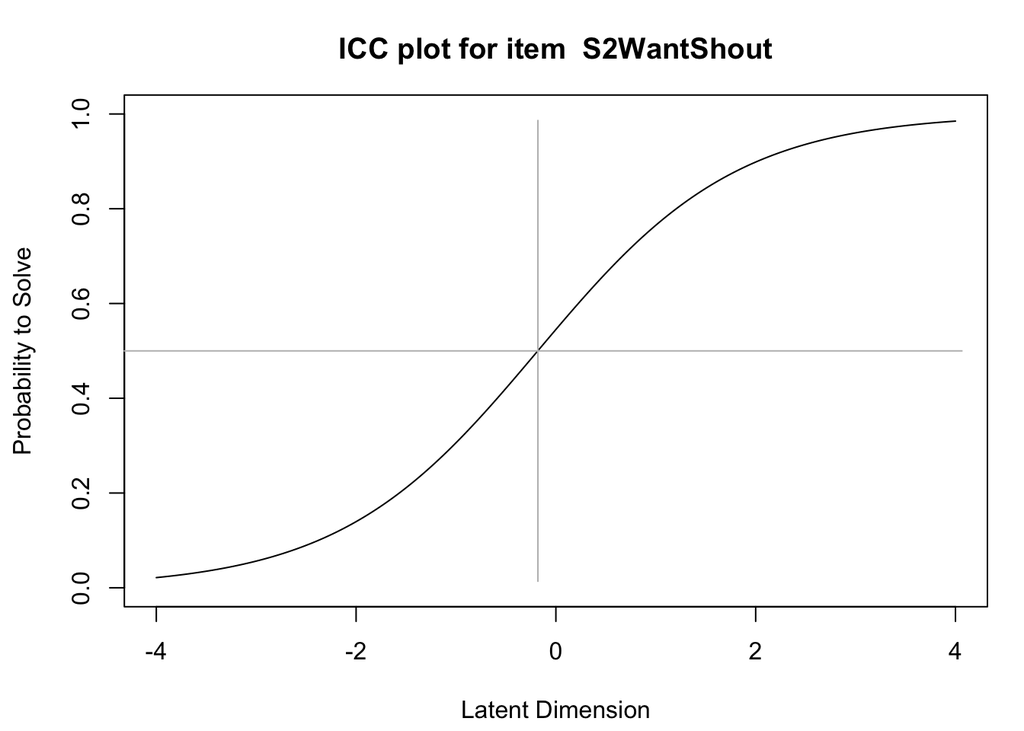

```r
plotICC(res.rm, item.subset = "S2WantShout")
abline(v = -0.18, col = "grey")
abline(h = .5, col = "grey")
```

对问题1-12和问题13-24分别绘制ICC，用以对比

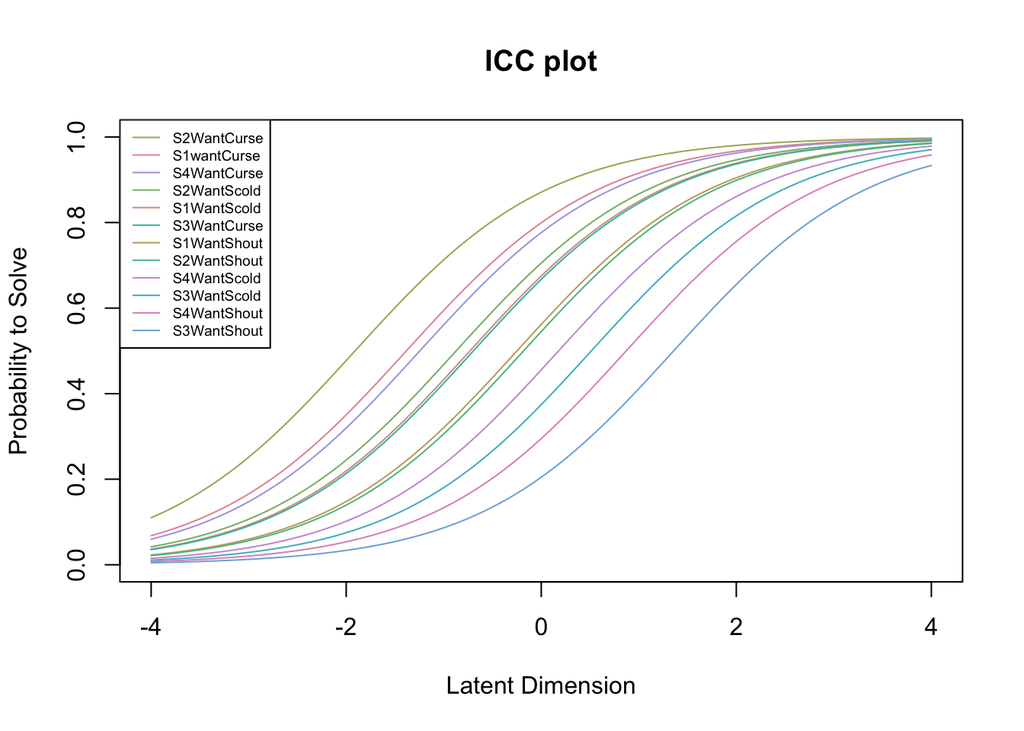

```r
plotjointICC(res.rm, item.subset =  1:12, cex = .6) # cex参数调整图例大小，设为0.6倍
```

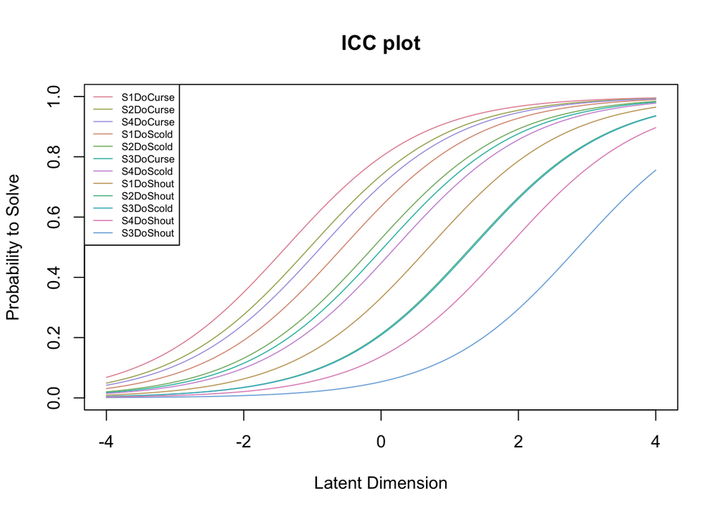

```r
plotjointICC(res.rm, item.subset = 13:24, cex = .6)
```

绘制人-问题对应图，上方直方图表示该能力值的人数，下方点图表示每个问题的能力值

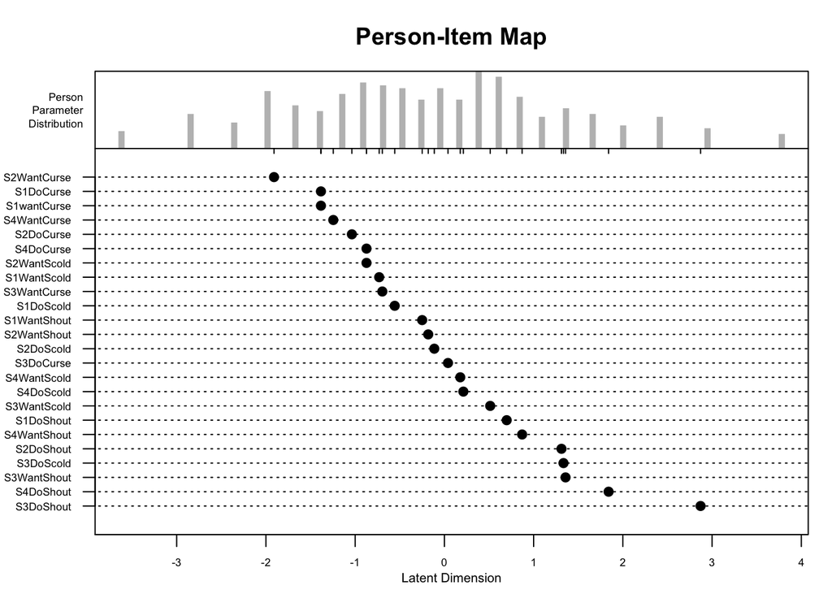

```r
plotPImap(res.rm, cex.gen = .55, sorted = TRUE)
```

## Eg2. b站案例

```r
list.of.packages <- c("eRm")
new.packages <- list.of.packages[!(list.of.packages %in% installed.packages()[,"Package"])]
if(length(new.packages)) install.packages(new.packages, repos = "http://cran.us.r-project.org")
lapply(list.of.packages, library, character.only = TRUE)

c2_rasch <- read.table('c2_rasch.dat')
ras.model <- RM(c2_rasch)
```

绘制项目特征曲线

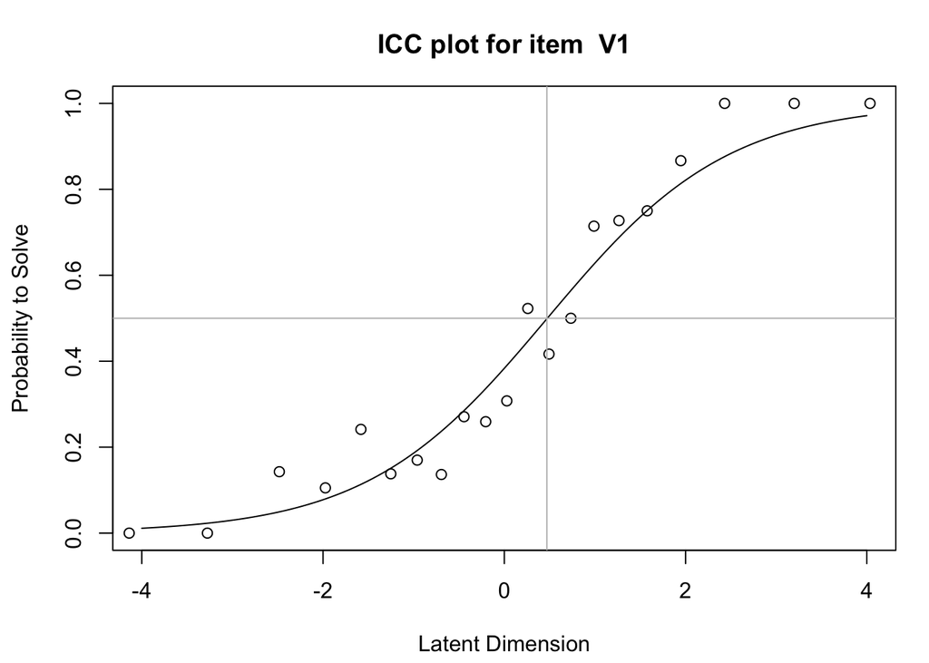

```r
plotICC(ras.model, empICC = list("raw"), item.subset = "V1") # 添加empICC项用于绘制点图
abline(v = 0.47, col = "grey")
abline(h = .5, col = "grey")
```

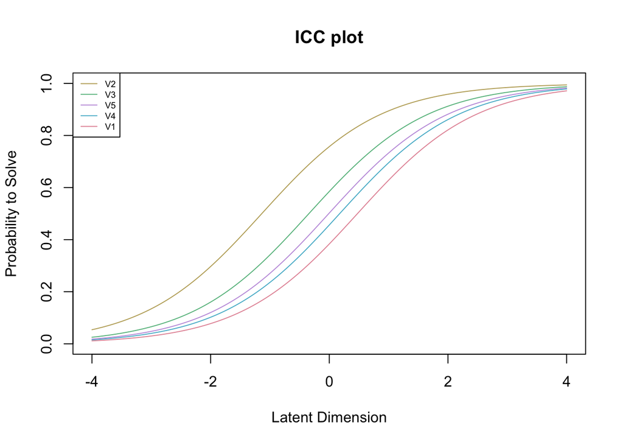

```r
plotjointICC(ras.model, item.subset = 1:5, cex = .6)
```

eRm提供了每个人的latent trait（能力分）的MLE：（总得分和相应的能力分的对照）

```r
personPara <- person.parameter(ras.model)
personPara
```

```
##
## Person Parameters:
##
##  Raw Score    Estimate Std.Error
##          0 -4.13917673        NA
##          1 -3.27618888 1.0485711
##          2 -2.48246502 0.7755980
##          3 -1.97443879 0.6609134
##          4 -1.58229252 0.5962473
##          5 -1.25249043 0.5548286
##          6 -0.96096554 0.5266115
##          7 -0.69445267 0.5069890
##          8 -0.44458232 0.4936149
##          9 -0.20540772 0.4852592
##         10  0.02782568 0.4813292
##         11  0.25932827 0.4816830
##         12  0.49331942 0.4865725
##         13  0.73455416 0.4967088
##         14  0.98906278 0.5134706
##         15  1.26526689 0.5393836
##         16  1.57659159 0.5792836
##         17  1.94734754 0.6435165
##         18  2.43132321 0.7592743
##         19  3.19894489 1.0357700
##         20  4.03542847        NA
```

## Eg3. Book *Rasch Measurement Theory Analysis in R*

### MFRM (Multi-Facet Rasch Model)

调用必要的包，其中:

- `TAM`：调用MFEM模型
- `WrightMap`：绘制怀特图
- `psych`：获取心理测量数据

```r
list.of.packages <- c("TAM", "WrightMap", "psych")
new.packages <- list.of.packages[!(list.of.packages %in% installed.packages()[,"Package"])]
if(length(new.packages)) install.packages(new.packages, repos = "http://cran.us.r-project.org")
lapply(list.of.packages, library, character.only = TRUE)
```

# 一些理论说明

Rasch模型可以看作是一个特殊的三参数比率模型（3-parameter logistic model），因此先介绍一下三参数比率模型的基本结构。

## Three-Parameter Logistic Model

模型的基本方程是：对于第$i$个人作答第$j$个问题，其答对的概率为
$$p_{ij}=p(\theta_i;
a_j,b_j,c_j)=c_j+(1-c_j)\frac{\mathrm{exp}[Da_j(\theta_i-b_j)]}{1+\mathrm{exp}[Da_j(\theta_i-b_j)]}.$$
将$\theta$视作连续自变量，$p_j(\theta)$的图像即为项目$j$的项目特征曲线（ICC）。

其中包含四个量，$\theta_i\in(-\infty,+\infty)$用来描述第$i$个学生的能力水平，$a_j, b_j, c_j$是用来描述第$j$个问题的三个参数。每个参数说明：

- 通常在做估计时，会事先假设$\theta$为标准正态分布，于是几乎所有人的$\theta$都应该在$(-3,3)$取值。
- $c_j$为$\theta\rightarrow-\infty$时的渐进值，即表示能力极低的学生做第$j$题时答对的概率，因此有时称为准运气参数或猜测度。
- $b_j$为难度，注意到$p_j(\theta)$图像上有一个拐点，该点即$\theta=b_j$点。该点可以描述为，当能力稍低于$b_j$时，答对该题的可能性较低；而当能力稍高于$b_j$时，答对该题的可能性骤升，即$b_j$是平均意义上刚好答对该题所需要的能力值。
- $a_j$为项目$j$的鉴别能力，其取值同特征曲线在$b_j$处的斜率成正比。当$a_j$越大，则特征曲线在$b_j$处更陡峭，能力稍微比$b_j$低一点点就几乎无法答对，能力比$b_j$高一点点就能答对，即项目$j$对能力的鉴别能力较强；当$a_j$较小时则反之。

概率表达式中还有一个字母$D$，是归一化常数，可取定为$D=1.7$不去管他。

## Classical Rasch Model

对上述模型特殊化，令$c_j=0$，$a_j=1$即为Rasch模型。这是，归一化参数取定为$D=1$，文献中通常会把上述的难度参数$b_j$记作$\beta_j$或$\delta_j$。此时第$i$个人答对第$j$个问题的概率为
$$p_{ij}=\frac{\mathrm{exp}(\theta_i-\beta_j)}{1+\mathrm{exp}(\theta_i-\beta_j)}.$$
即一个参数$\theta_i$表征能力，一个参数$\beta_j$表征题目难度，猜测度$c_j=0$即能力极低的人几乎不可能答对，且题目与题目间的鉴别能力都一致。

除了Rasch和三参数，还有常见的双参数比率对数模型，其令$c_j=0$而保留$a_j$和$b_j$作参数。

## PCM (Partial Credit Model) & RSM (Rating Scale Model)

用来衡量多指标而非0-1指标的量表。其仍为单模型参数的（one model-wide discrimination parameter），即用单个参数描述项目难度。因此，他们也可视作 Rasch 型的模型。

## GRM (Graded Response Model) & GPCM (Generalized Partial Credit Model)

他们是双参数模型，是 non-Rasch 的。

See [How should we select between various Item Response Theory Models? (E.g. RSM, GRM, LRSM, PCM)](https://stats.stackexchange.com/questions/402440/how-should-we-select-between-various-item-response-theory-models-e-g-rsm-grm)

## MFRM (Multi-Facet Rasch Model)

放弃单维能力假设，即将其他因素考虑到量表中，包括评分员打分严厉度、评分员一致性等等。

## Model Testing

### Fitness

在Rasch的集成软件中（如Winsteps），拟合度通常由 Outfit Mean Square (Outfit MNSQ) 和 Infit Mean Square (Infit MNSQ) 两个指标指示。

- Outfit MNSQ 是残差的均方，对极端值（异常数据）比较敏感。
- Infit MNSQ 则是加权（以方差为加权系数）后的残差均方，对题目难度与个体能力水平相当的数据较为敏感。

得到的结果为$(0,+\infty)$的数，$1$是拟合理想值，可接受的范围是$(0.5,1.5)$ [O’Connor et al., 2016]。

拟合度不好：可能存在其他变量造成干扰，或对所测量的特质不恰当。

### Reliability & Separation

可靠性或信度分为个体可靠性（被试的能力是否具有异质性，即个体是否能代表不一样的能力）和试题可靠性（是否能靠试题区分不同能力的被试者），$1$是理想值，一般可接受范围：个体$>.8$，试题$>.9$。

区分度也分个体区分度（选取的样本分离程度）和试题区分度（题目具有难度差异），一般要求个体$>2$，试题$>4$。

### 单一维度假设&局部独立假设

单一维度假设：量表问题具有一维性，即量表反映的是同一个潜在变量（这个假设在多面模型中是否还需要检验？）三个维度：

- 首成分残差特征值<3
- 首成分残差<.15
- 由量表解释的原始方差>.4

局部独立假设：问题之间的残差相关性应为0，即问题只通过待测的潜在特质相关联。判定：标准化残差<.3

### 试题差异

被试者和试题差异应相当。怀特图检验。